# Human Activity Recognition

Anh Mai

September 3, 2016

## Overall

Human Activity Recognition (HAR) is a key research area that is gaining increasing attention, especially for the development of context-aware systems. There are many potential applications for HAR, like: elderly monitoring, life log systems for monitoring energy expenditure and for supporting weight-loss programs, and digital assistants for weight lifting exercises. Using devices such as Jawbone Up, Nike FuelBand, and Fitbit it is now possible to collect a large amount of data about personal activity relatively inexpensively.  
In this assigment, we’ll predict the manner in which they did exercise. In order to do this, I build several methods for training data and choose the method having the best accuracy

## Data preparing

Firstly, we load some packages using for this assigment

```r
library(caret)
library(rpart)
```

Load data (assume that we’ve already downloaded the data into current workspace).

```r
pml_training <- read.csv("pml-training.csv")
pml_test <- read.csv("pml-testing.csv")
```

Clean the training data by removing the columns having NA or near zero values. The first 7 predictors are not useful to predict `classe` either.

```r
# Remove the first 7 columns
clean_training <- pml_training[, -(1:7)]
NZV_cols <- !nzv(clean_training, saveMetrics = TRUE)[, 4]
# Remove columns having near zero values
clean_training <- clean_training[, NZV_cols]
NA_cols <- sapply(clean_training, function (x) !any(is.na(x)))
# Remove columns having NA values
clean_training <- clean_training[, NA_cols]
names(clean_training)
```

```
##  [1] "roll_belt"            "pitch_belt"           "yaw_belt"
##  [4] "total_accel_belt"     "gyros_belt_x"         "gyros_belt_y"
##  [7] "gyros_belt_z"         "accel_belt_x"         "accel_belt_y"
## [10] "accel_belt_z"         "magnet_belt_x"        "magnet_belt_y"
## [13] "magnet_belt_z"        "roll_arm"             "pitch_arm"
## [16] "yaw_arm"              "total_accel_arm"      "gyros_arm_x"
## [19] "gyros_arm_y"          "gyros_arm_z"          "accel_arm_x"
## [22] "accel_arm_y"          "accel_arm_z"          "magnet_arm_x"
## [25] "magnet_arm_y"         "magnet_arm_z"         "roll_dumbbell"
## [28] "pitch_dumbbell"       "yaw_dumbbell"         "total_accel_dumbbell"
## [31] "gyros_dumbbell_x"     "gyros_dumbbell_y"     "gyros_dumbbell_z"
## [34] "accel_dumbbell_x"     "accel_dumbbell_y"     "accel_dumbbell_z"
## [37] "magnet_dumbbell_x"    "magnet_dumbbell_y"    "magnet_dumbbell_z"
## [40] "roll_forearm"         "pitch_forearm"        "yaw_forearm"
## [43] "total_accel_forearm"  "gyros_forearm_x"      "gyros_forearm_y"
## [46] "gyros_forearm_z"      "accel_forearm_x"      "accel_forearm_y"
## [49] "accel_forearm_z"      "magnet_forearm_x"     "magnet_forearm_y"
## [52] "magnet_forearm_z"     "classe"
```

Since the target of this assignment is predicting `classe` of `pml_test`, we’ll partition `clean_training` into training set and test set. Finally, we’ll set a seed for reproducibility.

```r
set.seed(7395)
in_train <- createDataPartition(y = clean_training$classe, p = 0.8, list = FALSE)
training <- clean_training[in_train, ]
test <- clean_training[-in_train, ]
```

## Model building

Now, we’ll use three different method: decision tree (`rpart`), stochastic gradient boosting tree (`gbm`) and random forest (`rf`) to predict and evalute the error to choose the best method.  
Firstly, we make a train control for doing cross validation.

```r
trControl <- trainControl(method = "cv", number = 5)
```

Build the three models

```r
mod_rpart <- train(classe ~ ., method = "rpart", trControl = trControl, data = training)
mod_gbm <- train(classe ~ ., method = "gbm", trControl = trControl, verbose = FALSE, data = training)
mod_rf <- train(classe ~ ., method = "rf", trControl = trControl, ntree = 100, data = training)
```

The plot for rpart model:

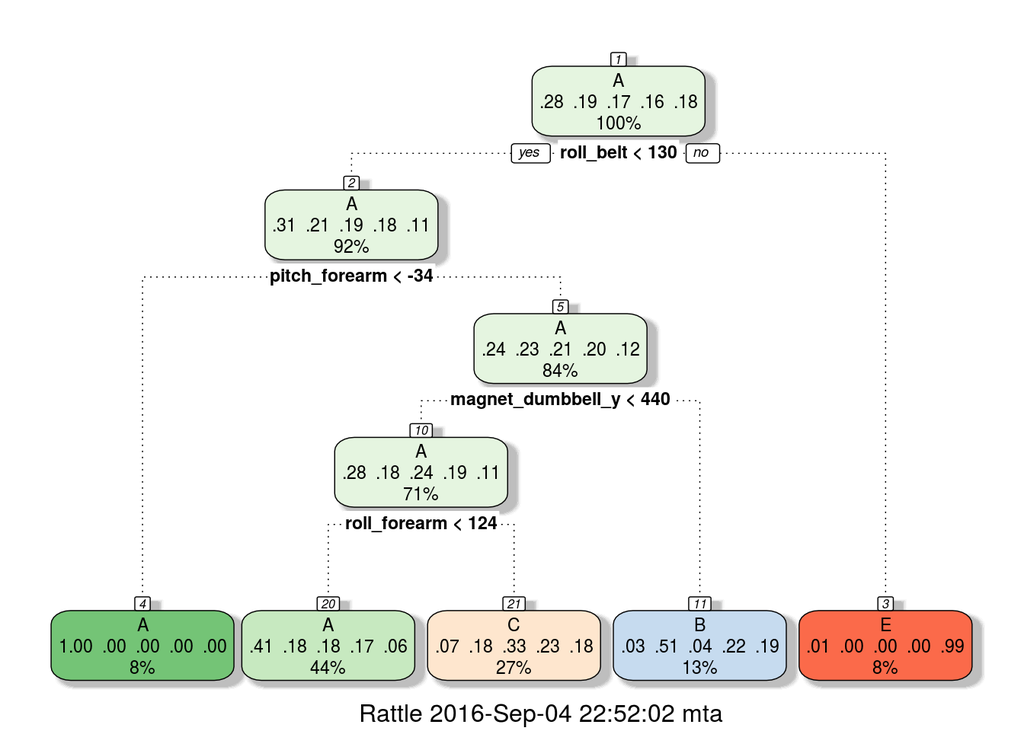

```r
library(rattle)
fancyRpartPlot(mod_rpart$finalModel)
```

Now we calculate the accuracy for each method with the test set

```r
pred_rpart <- predict(mod_rpart, newdata = test)
accuracy_rpart <- confusionMatrix(pred_rpart, test$classe)$overall[1]

pred_gbm <- predict(mod_gbm, newdata = test)
accuracy_gbm <- confusionMatrix(pred_gbm, test$classe)$overall[1]

pred_rf <- predict(mod_rf, newdata = test)
accuracy_rf <- confusionMatrix(pred_rf, test$classe)$overall[1]
```

The accuracy for each method:

| Method | Accuracy |
| --- | --- |
| rpart | 0.4858527 |
| gbm | 0.9620189 |
| rf | 0.9959215 |

We could see that `rpart` method does not have a good prediction, `gbm` is quite good with over 96% and `rf` has the best performance among such methods.  
Consequently, we’ll use random forest as our prediction method for such data.

## Apply model for prediction

Apply random forest model above for `pml_test`

```r
pred <- predict(mod_rf, newdata = pml_test)
result <- data.frame(test_id = 1:20, predict = pred)
result
```

```
##    test_id predict
## 1        1       B
## 2        2       A
## 3        3       B
## 4        4       A
## 5        5       A
## 6        6       E
## 7        7       D
## 8        8       B
## 9        9       A
## 10      10       A
## 11      11       B
## 12      12       C
## 13      13       B
## 14      14       A
## 15      15       E
## 16      16       E
## 17      17       A
## 18      18       B
## 19      19       B
## 20      20       B
```